# Supplementary Information – Nature Health analysis and manuscript

## Manuscript downloads

Download the complete manuscript (Word)

Individual editable tables are provided as Word documents.

- Table 1 (editable Word)
- Table 2 (editable Word)
- Table 3 (editable Word)
- Table S1 (editable Word)
- Table S2 (editable Word)
- Table S3 (editable Word)
- Table S4 (editable Word)
- Table S5 (editable Word)
- Table S6 (editable Word)
- Table S7 (editable Word)
- Table S8 (editable Word)
- Table S9 (editable Word)
- Table S10 (editable Word)
- Table S11a (editable Word)
- Table S11b (editable Word)
- Table S12 (editable Word)
- Table S13 (editable Word)
- Table S14 (editable Word)
- Table S15 (editable Word)

Passage changes (CSV) · Passage changes (Markdown) · Read the position, old and new text table

Return to the complete manuscript

# Supplementary Information

## Study support and exposure definitions

### Supplementary Table S1. Descriptive sample flow

**Descriptive sample flow and analytical support**

| Stage | Quantity | Count |
| --- | --- | --- |
| Participant roster |  |  |
| Available normalized participant metadata | Participants | 191 |
| Primary near-eye sensor position |  |  |
| At least 80% complete before all-zero screen | Participant-days | 818 |
| Exact all-zero days excluded | Participant-days | 2 |
| Final descriptive dataset | Participants | 141 |
| Final descriptive dataset | Participant-days | 816 |
| Final descriptive dataset | One-minute real observations | 1,175,160 |
| Complementary chest sensor position |  |  |
| At least 80% complete before all-zero screen | Participant-days | 905 |
| Exact all-zero days excluded | Participant-days | 3 |
| Final descriptive dataset | Participants | 154 |
| Final descriptive dataset | Participant-days | 902 |
| Final descriptive dataset | One-minute real observations | 1,298,880 |
| Paired main subset |  |  |
| Paired main subset | Participants | 112 |
| Paired main subset | Paired participant-days | 643 |

Counts use their stated denominator. An excluded participant-day is an all-zero day, not necessarily an excluded participant. The paired row reports paired participant-days, not minute-level observation pairs.

**Supplementary Table S1.** Participant, participant-day, and one-minute observation counts across the roster, sensor-specific completeness and all-zero screens, final descriptive datasets, and paired main subset. Each row names its denominator explicitly. An excluded participant-day is not necessarily an excluded participant.

### Supplementary Table S2. Full near-eye metric dictionary and distributions

Metric descriptive summary (near eye)

Metric<sup>1</sup>

Unit

Overall

Borås  
(SE)

Delft  
(NL)

Dortmund  
(DE)

Tübingen  
(DE)

Munich  
(DE)

Madrid  
(ES)

Izmir  
(TR)

San José  
(CR)

Kumasi  
(GH)

Scaling<sup>2</sup>

Distribution<sup>3</sup>

Duration

Time above 1,000 lx melEDI  
Bright-light exposure duration; relevant to daytime alerting and circadian entrainment.

HH:MM

**00:41**  
(00:11, 01:33)  
*01:10 ± 01:28*  
N=141; d=816

**01:18**  
(00:31, 03:24)  
*02:00 ± 01:54*  
N=13; d=78

**01:18**  
(00:29, 02:12)  
*01:33 ± 01:28*  
N=13; d=78

**01:03**  
(00:20, 02:32)  
*01:48 ± 02:14*  
N=18; d=107

**00:40**  
(00:07, 01:25)  
*01:06 ± 01:22*  
N=26; d=150

**00:39**  
(00:10, 01:46)  
*01:09 ± 01:18*  
N=10; d=60

**00:27**  
(00:06, 00:53)  
*00:38 ± 00:47*  
N=23; d=129

**00:30**  
(00:06, 01:04)  
*00:44 ± 00:51*  
N=17; d=101

**00:19**  
(00:09, 00:43)  
*00:32 ± 00:33*  
N=6; d=32

**00:43**  
(00:17, 01:14)  
*00:58 ± 00:57*  
N=15; d=81

Symlog (base 10; threshold 1)

Time above 1,000 lx melEDI distribution by site. Exact numerical summaries are in the adjacent cells.

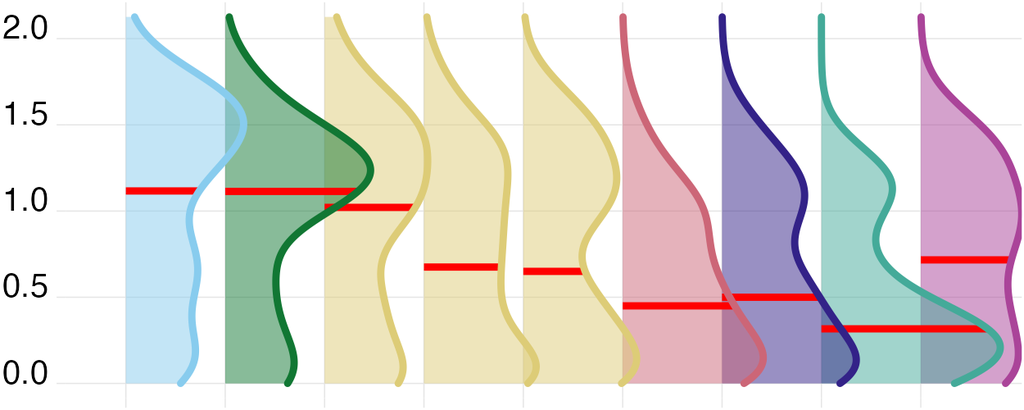

Time above 250 lx melEDI during wake  
Waking time in recommended daytime light; relevant to alertness, entrainment, and subsequent sleep.

HH:MM

**02:25**  
(00:51, 04:37)  
*03:00 ± 02:29*  
N=141; d=737

**04:06**  
(02:30, 06:15)  
*04:21 ± 02:24*  
N=13; d=73

**03:29**  
(02:03, 05:16)  
*03:39 ± 02:25*  
N=13; d=64

**03:42**  
(02:05, 05:58)  
*04:05 ± 02:51*  
N=18; d=90

**02:01**  
(00:47, 04:20)  
*02:52 ± 02:39*  
N=26; d=141

**02:38**  
(00:55, 04:19)  
*02:57 ± 02:19*  
N=10; d=54

**02:43**  
(00:54, 04:43)  
*03:02 ± 02:19*  
N=23; d=113

**01:30**  
(00:41, 03:26)  
*02:09 ± 01:57*  
N=17; d=94

**01:39**  
(00:33, 02:40)  
*01:48 ± 01:21*  
N=6; d=30

**01:14**  
(00:25, 02:37)  
*01:45 ± 01:46*  
N=15; d=78

Symlog (base 10; threshold 1)

Time above 250 lx melEDI during wake distribution by site. Exact numerical summaries are in the adjacent cells.

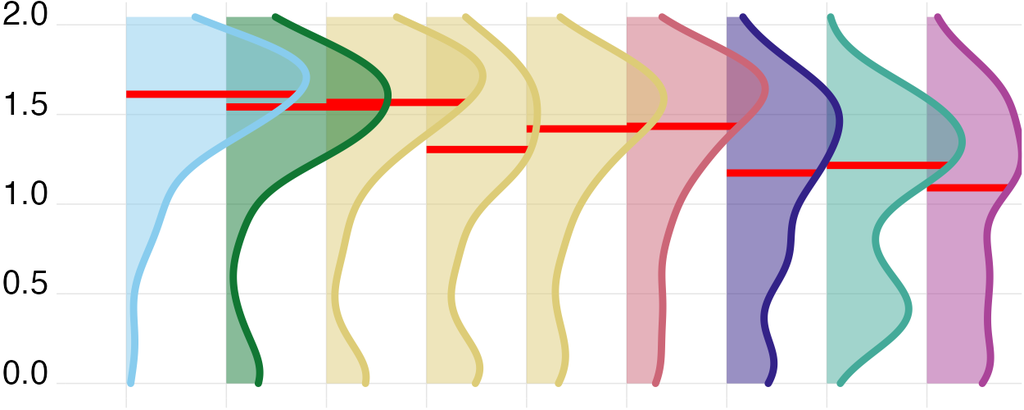

Time below 10 lx melEDI before sleep  
Low-light time before bed; limits evening melatonin suppression and circadian delay.

HH:MM

**01:53**  
(01:01, 02:35)  
*01:51 ± 01:02*  
N=139; d=655

**02:16**  
(01:30, 02:39)  
*02:05 ± 00:53*  
N=13; d=67

**01:50**  
(01:21, 02:52)  
*01:59 ± 00:57*  
N=12; d=50

**01:42**  
(00:53, 02:17)  
*01:41 ± 00:58*  
N=18; d=84

**01:52**  
(01:04, 02:25)  
*01:52 ± 01:06*  
N=26; d=132

**01:43**  
(00:42, 02:32)  
*01:45 ± 01:10*  
N=10; d=52

**01:43**  
(00:58, 02:50)  
*01:50 ± 01:05*  
N=23; d=105

**01:31**  
(00:49, 02:15)  
*01:38 ± 01:00*  
N=17; d=82

**02:16**  
(01:15, 02:39)  
*01:56 ± 01:00*  
N=6; d=25

**02:30**  
(01:28, 02:52)  
*02:09 ± 00:57*  
N=14; d=58

Symlog (base 10; threshold 1)

Time below 10 lx melEDI before sleep distribution by site. Exact numerical summaries are in the adjacent cells.

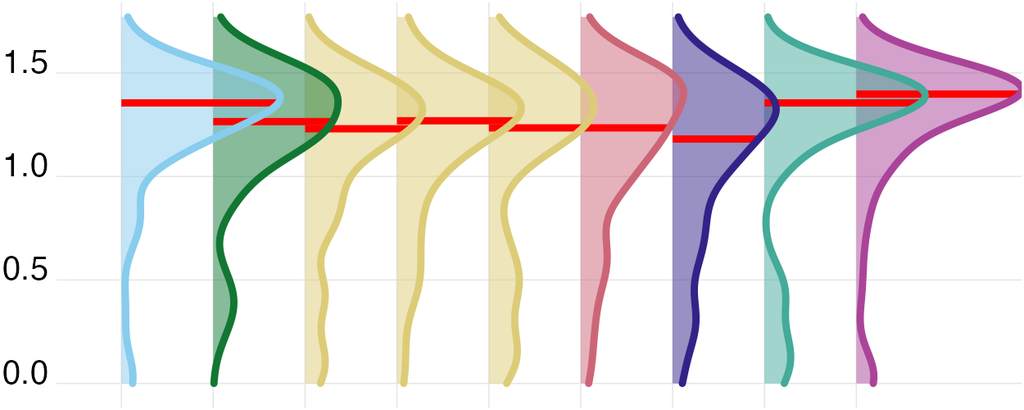

Time below 1 lx melEDI during sleep  
Darkness during sleep; supports nocturnal melatonin and an undisturbed sleep environment.

HH:MM

**07:08**  
(05:58, 08:15)  
*07:04 ± 01:57*  
N=141; d=778

**07:08**  
(06:03, 08:18)  
*07:12 ± 01:46*  
N=13; d=76

**07:14**  
(05:56, 08:06)  
*07:01 ± 01:50*  
N=13; d=68

**07:08**  
(05:56, 08:16)  
*07:05 ± 01:50*  
N=18; d=95

**06:54**  
(05:51, 07:46)  
*06:47 ± 01:30*  
N=26; d=150

**05:52**  
(04:41, 07:03)  
*05:58 ± 01:58*  
N=10; d=60

**08:06**  
(07:10, 09:10)  
*08:02 ± 01:57*  
N=23; d=118

**06:45**  
(05:08, 08:15)  
*06:40 ± 02:07*  
N=17; d=99

**06:56**  
(06:06, 07:36)  
*06:39 ± 01:43*  
N=6; d=31

**07:31**  
(06:31, 09:00)  
*07:35 ± 02:15*  
N=15; d=81

Symlog (base 10; threshold 1)

Time below 1 lx melEDI during sleep distribution by site. Exact numerical summaries are in the adjacent cells.

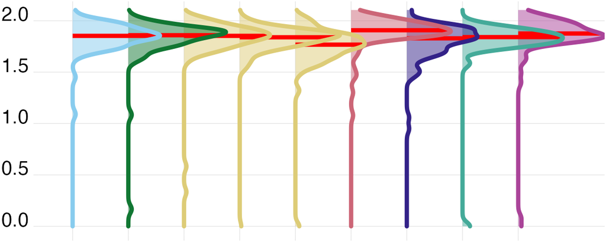

Longest period above 250 lx melEDI  
Longest sustained bright-light bout; captures continuity of daytime circadian stimulation.

HH:MM

**00:38**  
(00:17, 01:12)  
*00:55 ± 01:00*  
N=141; d=816

**00:57**  
(00:28, 01:27)  
*01:12 ± 01:02*  
N=13; d=78

**00:48**  
(00:23, 01:20)  
*01:09 ± 01:15*  
N=13; d=78

**01:00**  
(00:21, 01:40)  
*01:20 ± 01:31*  
N=18; d=107

**00:35**  
(00:13, 01:06)  
*00:50 ± 00:54*  
N=26; d=150

**00:38**  
(00:17, 01:32)  
*01:01 ± 01:02*  
N=10; d=60

**00:38**  
(00:16, 01:04)  
*00:45 ± 00:36*  
N=23; d=129

**00:34**  
(00:14, 00:55)  
*00:43 ± 00:41*  
N=17; d=101

**00:28**  
(00:16, 00:43)  
*00:30 ± 00:20*  
N=6; d=32

**00:23**  
(00:15, 00:49)  
*00:38 ± 00:45*  
N=15; d=81

Symlog (base 10; threshold 1)

Longest period above 250 lx melEDI distribution by site. Exact numerical summaries are in the adjacent cells.

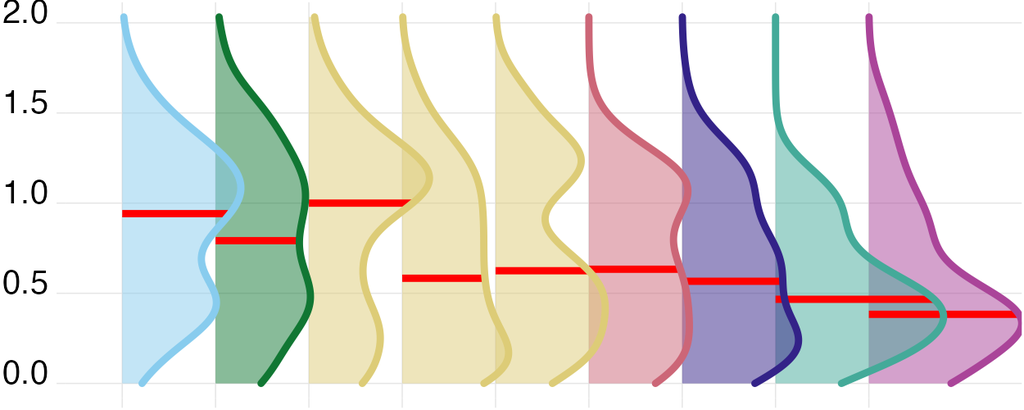

Dynamics

Interdaily stability  
Day-to-day regularity of the light–dark pattern; higher regularity supports circadian stability.

—

**0.308**  
(0.248, 0.38)  
*0.318 ± 0.095*  
N=141; d=816

**0.311**  
(0.272, 0.367)  
*0.315 ± 0.078*  
N=13; d=78

**0.258**  
(0.239, 0.389)  
*0.288 ± 0.094*  
N=13; d=78

**0.264**  
(0.219, 0.319)  
*0.274 ± 0.074*  
N=18; d=107

**0.329**  
(0.263, 0.424)  
*0.344 ± 0.107*  
N=26; d=150

**0.244**  
(0.218, 0.277)  
*0.252 ± 0.058*  
N=10; d=60

**0.352**  
(0.321, 0.455)  
*0.368 ± 0.092*  
N=23; d=129

**0.278**  
(0.254, 0.394)  
*0.323 ± 0.104*  
N=17; d=101

**0.342**  
(0.315, 0.473)  
*0.37 ± 0.118*  
N=6; d=32

**0.293**  
(0.255, 0.354)  
*0.299 ± 0.062*  
N=15; d=81

Identity

Interdaily stability distribution by site. Exact numerical summaries are in the adjacent cells.

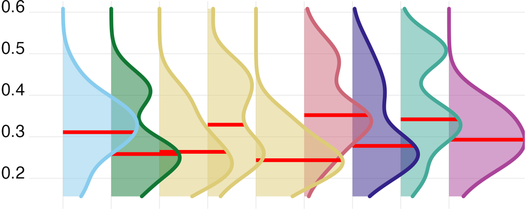

Intradaily variability  
Within-day fragmentation of light exposure; higher values indicate less consolidated light–dark input.

—

**1.253**  
(0.93, 1.502)  
*1.229 ± 0.389*  
N=141; d=816

**0.997**  
(0.818, 1.388)  
*1.088 ± 0.343*  
N=13; d=78

**1.193**  
(0.96, 1.389)  
*1.238 ± 0.345*  
N=13; d=78

**1.182**  
(0.928, 1.49)  
*1.177 ± 0.407*  
N=18; d=107

**1.154**  
(0.801, 1.442)  
*1.125 ± 0.354*  
N=26; d=150

**1.48**  
(0.869, 1.642)  
*1.332 ± 0.477*  
N=10; d=60

**1.251**  
(0.999, 1.497)  
*1.251 ± 0.413*  
N=23; d=129

**1.359**  
(0.95, 1.546)  
*1.307 ± 0.415*  
N=17; d=101

**1.399**  
(1.282, 1.483)  
*1.355 ± 0.256*  
N=6; d=32

**1.324**  
(1.029, 1.595)  
*1.344 ± 0.413*  
N=15; d=81

Identity

Intradaily variability distribution by site. Exact numerical summaries are in the adjacent cells.

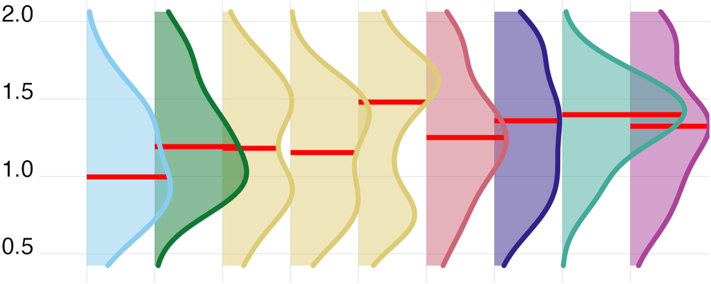

Exposure history

melEDI dose  
Intensity–duration-weighted melanopic exposure; summarizes cumulative non-visual retinal light input.

klx·h

**4.96**  
(1.936, 12.313)  
*10.358 ± 16.216*  
N=141; d=761

**9.296**  
(3.892, 21.895)  
*19.923 ± 27.784*  
N=13; d=71

**10.495**  
(3.855, 17.395)  
*15.881 ± 20.395*  
N=13; d=74

**6.751**  
(2.469, 14.435)  
*13.809 ± 23.711*  
N=18; d=97

**3.862**  
(1.411, 10.217)  
*7.719 ± 9.847*  
N=26; d=137

**7.11**  
(1.897, 15.789)  
*10.055 ± 11.237*  
N=10; d=55

**3.317**  
(1.703, 6.29)  
*6.115 ± 8.79*  
N=23; d=125

**4.35**  
(1.791, 10.625)  
*7.49 ± 8.898*  
N=17; d=96

**2.195**  
(1.339, 4.117)  
*3.281 ± 2.573*  
N=6; d=30

**6.045**  
(2.49, 14.907)  
*10.016 ± 10.799*  
N=15; d=76

Symlog (base 10; threshold 1)

melEDI dose distribution by site. Exact numerical summaries are in the adjacent cells.

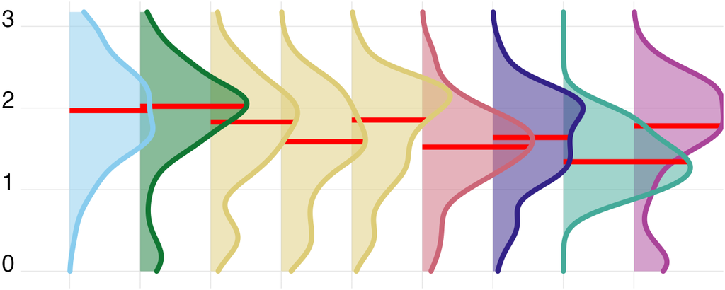

Level

Mean melEDI  
Geometric average of daily melEDI values, including zeros; summarizes overall exposure while reducing peak influence.

lx

**5.154**  
(2.831, 9.225)  
*7.587 ± 9.496*  
N=141; d=816

**7.569**  
(4.55, 11.613)  
*9.171 ± 7.111*  
N=13; d=78

**6.659**  
(4.18, 11.674)  
*8.274 ± 6.558*  
N=13; d=78

**7.704**  
(3.081, 13.924)  
*12.017 ± 18.865*  
N=18; d=107

**5.232**  
(3.224, 8.188)  
*7.221 ± 6.33*  
N=26; d=150

**9.013**  
(4.011, 15.089)  
*12.102 ± 12.013*  
N=10; d=60

**3.505**  
(1.469, 6.211)  
*4.166 ± 3.272*  
N=23; d=129

**5.857**  
(3.726, 7.986)  
*7.778 ± 6.946*  
N=17; d=101

**4.325**  
(3.585, 6.77)  
*5.248 ± 2.85*  
N=6; d=32

**2.144**  
(0.744, 4.042)  
*3.019 ± 2.896*  
N=15; d=81

Symlog (base 10; threshold 1)

Mean melEDI distribution by site. Exact numerical summaries are in the adjacent cells.

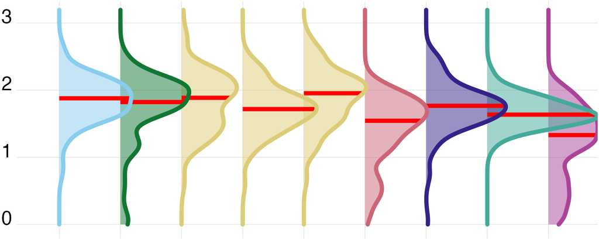

Brightest 10 h mean  
Mean of the brightest 10 hours; reflects the strength of the main daytime light episode.

lx

**110.566**  
(41.513, 243.212)  
*214.866 ± 508.56*  
N=141; d=816

**252.689**  
(104.514, 461.953)  
*399.302 ± 518.102*  
N=13; d=78

**175.974**  
(78.625, 299.106)  
*262.206 ± 329.201*  
N=13; d=78

**156.184**  
(67.783, 339.731)  
*422.54 ± 1,209.616*  
N=18; d=107

**100.057**  
(33.255, 209.904)  
*179.372 ± 241.53*  
N=26; d=150

**130.78**  
(54.044, 259.726)  
*201.947 ± 194.042*  
N=10; d=60

**101.102**  
(24.355, 218.457)  
*136.312 ± 134.07*  
N=23; d=129

**83.24**  
(53.17, 151.786)  
*120.172 ± 101.545*  
N=17; d=101

**68.143**  
(45.331, 132.458)  
*96.735 ± 72.311*  
N=6; d=32

**46.66**  
(9.242, 103.175)  
*82.489 ± 115.07*  
N=15; d=81

Symlog (base 10; threshold 1)

Brightest 10 h mean distribution by site. Exact numerical summaries are in the adjacent cells.

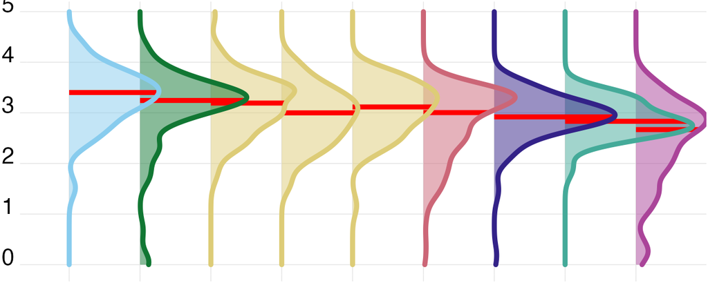

Darkest 10 h mean  
Mean of the darkest 10 hours; lower values during the biological night favour melatonin preservation and sleep.

lx

**0.103**  
(0.02, 0.253)  
*0.243 ± 0.513*  
N=141; d=816

**0.08**  
(0.016, 0.191)  
*0.183 ± 0.299*  
N=13; d=78

**0.1**  
(0.035, 0.23)  
*0.2 ± 0.332*  
N=13; d=78

**0.14**  
(0.036, 0.282)  
*0.223 ± 0.299*  
N=18; d=107

**0.149**  
(0.074, 0.309)  
*0.273 ± 0.465*  
N=26; d=150

**0.325**  
(0.119, 0.71)  
*0.515 ± 0.653*  
N=10; d=60

**0.022**  
(0, 0.08)  
*0.054 ± 0.075*  
N=23; d=129

**0.152**  
(0.052, 0.481)  
*0.475 ± 0.882*  
N=17; d=101

**0.133**  
(0.055, 0.309)  
*0.411 ± 1.044*  
N=6; d=32

**0.01**  
(0, 0.092)  
*0.059 ± 0.104*  
N=15; d=81

Symlog (base 10; threshold 1)

Darkest 10 h mean distribution by site. Exact numerical summaries are in the adjacent cells.

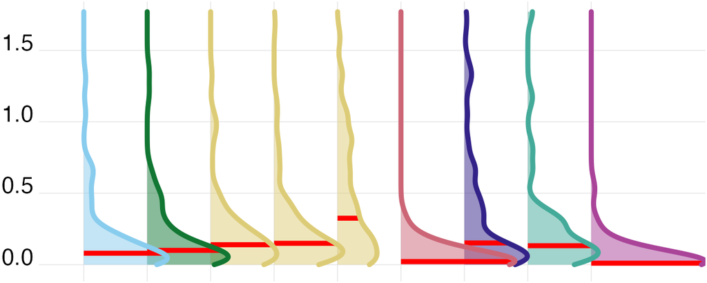

Spectrum

Melanopic daylight efficacy ratio  
Mean of viable one-minute melEDI/illuminance ratios; indicates melanopic efficacy relative to visual light.

—

**0.724**  
(0.643, 0.795)  
*0.724 ± 0.116*  
N=137; d=687

**0.788**  
(0.725, 0.872)  
*0.796 ± 0.162*  
N=13; d=74

**0.743**  
(0.699, 0.796)  
*0.743 ± 0.077*  
N=13; d=65

**0.781**  
(0.675, 0.853)  
*0.768 ± 0.118*  
N=18; d=97

**0.65**  
(0.592, 0.728)  
*0.667 ± 0.098*  
N=26; d=144

**0.724**  
(0.652, 0.773)  
*0.72 ± 0.093*  
N=10; d=55

**0.668**  
(0.629, 0.721)  
*0.673 ± 0.07*  
N=22; d=83

**0.747**  
(0.634, 0.834)  
*0.735 ± 0.122*  
N=17; d=91

**0.719**  
(0.661, 0.761)  
*0.706 ± 0.067*  
N=6; d=30

**0.755**  
(0.729, 0.82)  
*0.758 ± 0.097*  
N=12; d=48

Identity

Melanopic daylight efficacy ratio distribution by site. Exact numerical summaries are in the adjacent cells.

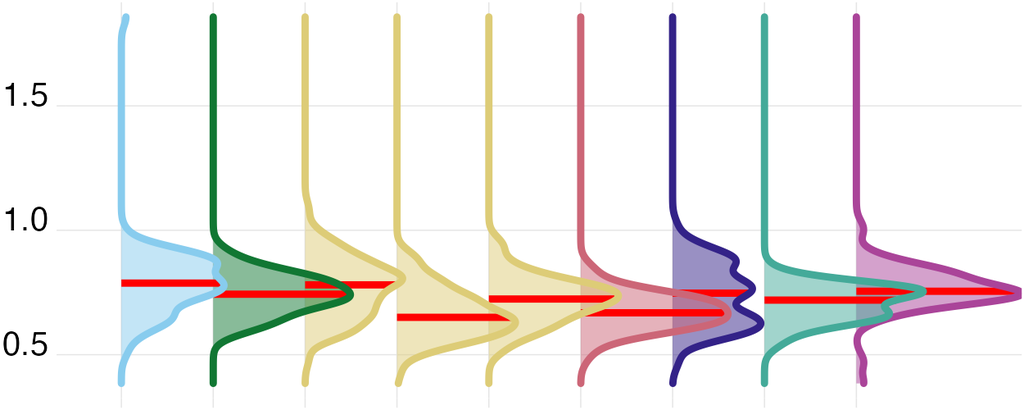

Timing

Midpoint of the brightest 10 hours  
Centre time of the brightest 10 hours; indexes the main daily circadian light cue.

HH:MM  
clock time

**13:44**  
(12:48, 15:00)  
*13:56 ± 01:51*  
N=141; d=816

**13:16**  
(12:28, 14:10)  
*13:20 ± 01:33*  
N=13; d=78

**14:12**  
(13:23, 15:18)  
*14:22 ± 01:51*  
N=13; d=78

**13:52**  
(12:54, 15:04)  
*14:00 ± 01:42*  
N=18; d=107

**13:38**  
(12:47, 14:44)  
*13:52 ± 01:42*  
N=26; d=150

**14:54**  
(12:50, 16:03)  
*14:31 ± 02:14*  
N=10; d=60

**13:44**  
(13:06, 15:20)  
*14:10 ± 01:51*  
N=23; d=129

**14:10**  
(13:32, 15:21)  
*14:25 ± 01:37*  
N=17; d=101

**12:34**  
(11:49, 14:02)  
*12:55 ± 01:44*  
N=6; d=32

**12:49**  
(12:06, 13:39)  
*13:03 ± 01:58*  
N=15; d=81

Circular clock

Midpoint of the brightest 10 hours distribution by site. Exact numerical summaries are in the adjacent cells.

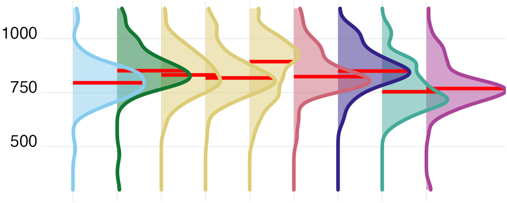

Midpoint of the darkest 10 hours  
Centre time of the darkest 10 hours; indexes the main daily darkness cue.

HH:MM  
clock time

**02:54**  
(02:01, 03:50)  
*02:58 ± 01:41*  
N=141; d=816

**02:02**  
(01:25, 02:48)  
*02:03 ± 01:07*  
N=13; d=78

**02:55**  
(02:01, 03:27)  
*02:50 ± 02:05*  
N=13; d=78

**02:32**  
(01:45, 03:22)  
*02:37 ± 01:19*  
N=18; d=107

**03:08**  
(02:11, 04:10)  
*03:16 ± 01:34*  
N=26; d=150

**02:37**  
(01:54, 04:17)  
*03:10 ± 02:00*  
N=10; d=60

**03:39**  
(02:43, 04:34)  
*03:34 ± 01:49*  
N=23; d=129

**03:31**  
(02:33, 04:14)  
*03:26 ± 01:25*  
N=17; d=101

**01:45**  
(01:05, 03:01)  
*02:10 ± 01:27*  
N=6; d=32

**02:33**  
(02:04, 03:17)  
*02:36 ± 01:36*  
N=15; d=81

Circular clock

Midpoint of the darkest 10 hours distribution by site. Exact numerical summaries are in the adjacent cells.

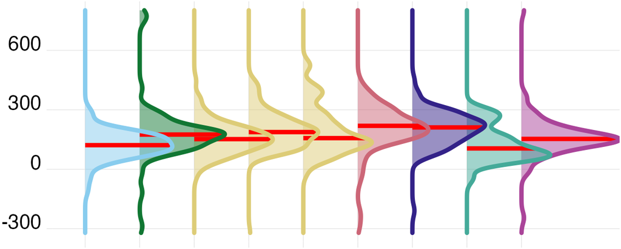

First light timing above 250 lx melEDI  
First waking bright-light exposure; morning timing can advance circadian phase and promote alertness.

HH:MM  
clock time

**09:08**  
(08:02, 10:40)  
*09:26 ± 02:22*  
N=140; d=727

**07:57**  
(06:56, 08:33)  
*08:03 ± 01:32*  
N=13; d=74

**09:04**  
(08:18, 09:52)  
*09:17 ± 01:56*  
N=13; d=68

**08:36**  
(07:10, 10:13)  
*08:45 ± 02:21*  
N=18; d=93

**09:43**  
(08:13, 10:53)  
*09:45 ± 02:21*  
N=25; d=133

**09:36**  
(07:58, 10:53)  
*09:39 ± 03:12*  
N=10; d=56

**09:32**  
(08:40, 11:21)  
*10:05 ± 02:18*  
N=23; d=118

**10:01**  
(09:06, 11:52)  
*10:26 ± 02:28*  
N=17; d=95

**08:11**  
(07:26, 09:57)  
*08:36 ± 01:30*  
N=6; d=29

**08:43**  
(08:01, 10:10)  
*09:19 ± 01:52*  
N=15; d=61

Circular clock

First light timing above 250 lx melEDI distribution by site. Exact numerical summaries are in the adjacent cells.

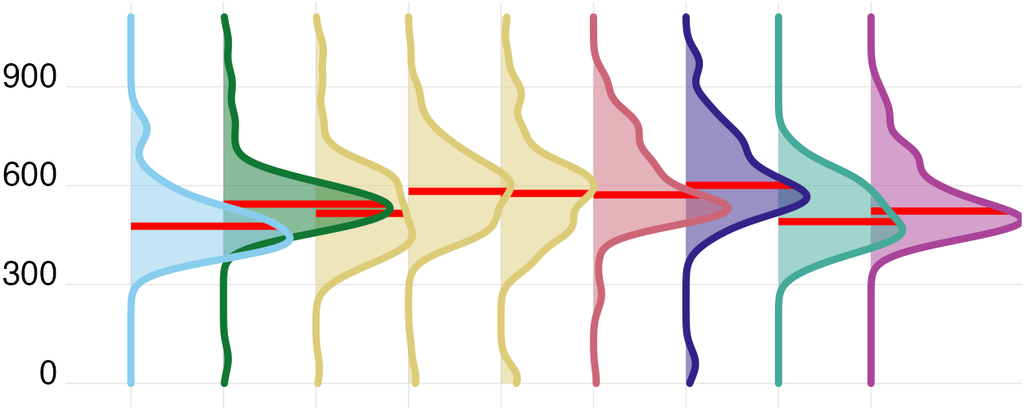

Last light timing above 250 lx melEDI  
Last bright-light exposure; later timing may delay circadian phase and sleep onset.

HH:MM  
clock time

**18:08**  
(16:27, 19:42)  
*18:03 ± 02:36*  
N=141; d=687

**18:41**  
(17:38, 19:38)  
*18:39 ± 01:38*  
N=13; d=73

**18:30**  
(17:37, 19:59)  
*18:37 ± 02:08*  
N=13; d=62

**19:34**  
(18:04, 20:42)  
*19:16 ± 02:28*  
N=18; d=89

**17:37**  
(15:35, 19:09)  
*17:18 ± 02:44*  
N=26; d=121

**19:50**  
(18:37, 20:50)  
*19:33 ± 02:11*  
N=10; d=53

**17:48**  
(16:46, 19:19)  
*18:01 ± 02:21*  
N=23; d=106

**18:45**  
(17:02, 19:38)  
*18:23 ± 02:15*  
N=17; d=89

**15:45**  
(13:20, 16:38)  
*15:22 ± 02:38*  
N=6; d=28

**15:54**  
(14:34, 17:25)  
*15:46 ± 02:13*  
N=15; d=66

Circular clock

Last light timing above 250 lx melEDI distribution by site. Exact numerical summaries are in the adjacent cells.

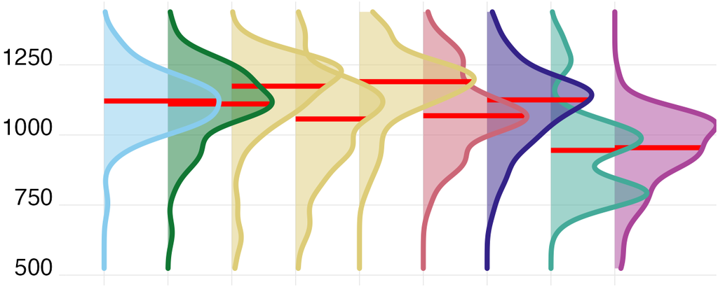

Mean timing of exposure above 250 lx melEDI  
Average bright-light timing; summarizes the phase of daily circadian stimulation.

HH:MM  
clock time

**13:29**  
(12:29, 14:39)  
*13:31 ± 01:52*  
N=141; d=742

**13:20**  
(12:29, 14:24)  
*13:21 ± 01:25*  
N=13; d=72

**13:52**  
(13:13, 15:06)  
*14:02 ± 01:41*  
N=13; d=71

**13:44**  
(12:28, 14:55)  
*13:51 ± 01:56*  
N=18; d=93

**13:17**  
(12:17, 14:31)  
*13:24 ± 01:45*  
N=26; d=138

**14:04**  
(12:58, 15:25)  
*14:09 ± 02:22*  
N=10; d=55

**13:43**  
(12:55, 14:29)  
*13:47 ± 01:33*  
N=23; d=117

**13:58**  
(12:54, 14:58)  
*14:04 ± 01:39*  
N=17; d=94

**11:30**  
(10:28, 12:38)  
*11:26 ± 01:36*  
N=6; d=31

**12:17**  
(11:04, 13:04)  
*12:11 ± 01:36*  
N=15; d=71

Circular clock

Mean timing of exposure above 250 lx melEDI distribution by site. Exact numerical summaries are in the adjacent cells.

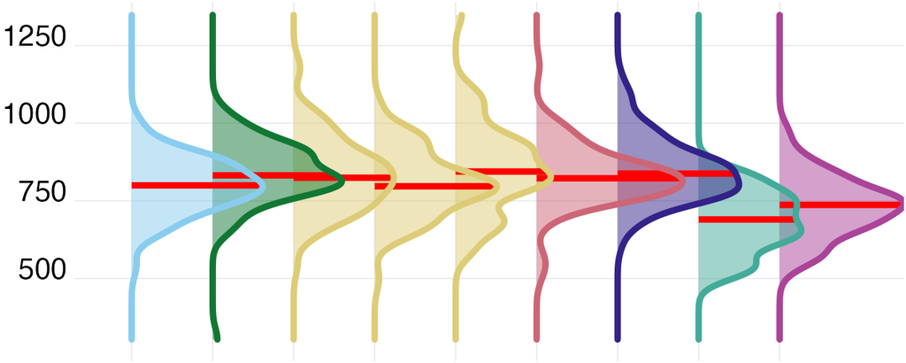

**Median** (25th percentile, 75th percentile), *circular or arithmetic mean ± standard deviation*, N=participants; d=participant-days with a finite value for that metric.

<sup>1</sup> The brief meaning and relevance notes describe established physiological constructs; this descriptive table does not estimate individual health effects.

<sup>2</sup> Scaling describes the distribution column only; printed values remain on their stated scale. Symlog uses base 10 with a linear region through 1 in the stated unit; Identity is linear; Circular clock unwraps values around the metric-specific clock centre.

<sup>3</sup> Red lines indicate site medians. Symlog and circular-clock rows are transformed only for plotting.

**Supplementary Table S2.** Definitions, exact support, median (interquartile range) summaries, and density displays for the 17 near-eye personal light-exposure metrics overall and by site. Values use three decimal places where applicable. Metrics are distinct summaries and should not be interpreted as interchangeable outcomes.

### Supplementary Table S3. Descriptive recommendation-range fractions

| Site<sup>1</sup> | Minutes in the recommended range:<sup>2</sup> Daytime | Minutes in the recommended range:<sup>2</sup> Pre-sleep | Minutes in the recommended range:<sup>2</sup> Sleep<sup>4</sup> | Minutes in the recommended range:<sup>2</sup> Total<sup>5</sup> | Share of all eligible real minutes:<sup>3</sup> Daytime | Share of all eligible real minutes:<sup>3</sup> Pre-sleep | Share of all eligible real minutes:<sup>3</sup> Sleep | Share of all eligible real minutes:<sup>3</sup> Unclassified<sup>6</sup> |
| --- | --- | --- | --- | --- | --- | --- | --- | --- |
| Overall | **24.0%** 137,792 / 573,712 | **63.3%** 81,894 / 129,390 | **87.7%** 336,052 / 383,366 | **51.2%** 555,738 / 1,086,468 | **51.6%** 606,215 / 1,175,160 | **11.9%** 140,152 / 1,175,160 | **32.6%** 383,607 / 1,175,160 | **3.8%** 45,186 / 1,175,160 |
| Borås (SE) | **33.2%** 19,225 / 57,952 | **69.9%** 8,914 / 12,759 | **93.4%** 33,152 / 35,489 | **57.7%** 61,291 / 106,200 | **54.0%** 60,642 / 112,260 | **12.2%** 13,704 / 112,260 | **31.7%** 35,549 / 112,260 | **2.1%** 2,365 / 112,260 |
| Delft (NL) | **29.6%** 14,760 / 49,852 | **66.7%** 7,181 / 10,774 | **86.4%** 29,915 / 34,621 | **54.4%** 51,856 / 95,247 | **47.0%** 52,755 / 112,260 | **10.9%** 12,283 / 112,260 | **30.9%** 34,682 / 112,260 | **11.2%** 12,540 / 112,260 |
| Dortmund (DE) | **32.4%** 22,631 / 69,900 | **59.6%** 9,749 / 16,361 | **87.5%** 42,829 / 48,928 | **55.6%** 75,209 / 135,189 | **48.1%** 74,094 / 154,080 | **11.3%** 17,409 / 154,080 | **31.8%** 48,928 / 154,080 | **8.9%** 13,649 / 154,080 |
| Tübingen (DE) | **22.5%** 25,082 / 111,396 | **61.8%** 15,623 / 25,283 | **87.1%** 61,030 / 70,029 | **49.2%** 101,735 / 206,708 | **55.1%** 119,150 / 216,120 | **12.4%** 26,881 / 216,120 | **32.4%** 70,089 / 216,120 | **0.0%** 0 / 216,120 |
| Munich (DE) | **25.0%** 10,681 / 42,685 | **60.6%** 5,963 / 9,833 | **71.7%** 21,485 / 29,951 | **46.2%** 38,129 / 82,469 | **53.0%** 45,831 / 86,400 | **12.3%** 10,618 / 86,400 | **34.7%** 29,951 / 86,400 | **0.0%** 0 / 86,400 |
| Madrid (ES) | **24.2%** 21,067 / 87,030 | **62.7%** 12,766 / 20,366 | **95.9%** 58,374 / 60,891 | **54.8%** 92,207 / 168,287 | **48.4%** 89,948 / 185,880 | **11.7%** 21,684 / 185,880 | **32.8%** 60,891 / 185,880 | **7.2%** 13,357 / 185,880 |
| Izmir (TR) | **17.8%** 12,708 / 71,562 | **55.1%** 9,221 / 16,736 | **79.0%** 39,936 / 50,556 | **44.6%** 61,865 / 138,854 | **51.5%** 74,926 / 145,440 | **12.3%** 17,883 / 145,440 | **34.8%** 50,556 / 145,440 | **1.4%** 2,075 / 145,440 |
| San José (CR) | **13.8%** 3,266 / 23,640 | **64.6%** 3,124 / 4,839 | **87.1%** 12,438 / 14,275 | **44.0%** 18,828 / 42,754 | **54.9%** 25,285 / 46,080 | **11.5%** 5,320 / 46,080 | **31.0%** 14,275 / 46,080 | **2.6%** 1,200 / 46,080 |
| Kumasi (GH) | **14.0%** 8,372 / 59,695 | **75.2%** 9,353 / 12,439 | **95.5%** 36,893 / 38,626 | **49.3%** 54,618 / 110,760 | **54.5%** 63,584 / 116,640 | **12.3%** 14,370 / 116,640 | **33.2%** 38,686 / 116,640 | **0.0%** 0 / 116,640 |

<sup>1</sup> Near eye participant and participant-day sample sizes are reported in the participant table; every percentage cell gives its exact minute denominator.  
<sup>2</sup> Recommended ranges follow Brown et al. (2022): Daytime ≥250 lx melanopic EDI, Pre-sleep ≤10 lx melanopic EDI, and Sleep ≤1 lx melanopic EDI. Daytime, Pre-sleep, and Sleep identify the recommendation windows. Each grey numerator/denominator gives minutes within the applicable recommendation range over all valid one-minute observations in that window. Sleep describes the bedside sleep environment.  
<sup>3</sup> Each grey relevant / all count gives minutes in the displayed diary state over all eligible real minutes before classification by diary state or measurement availability.  
<sup>4</sup> During diary-defined sleep the bedside sensor describes the sleep environment rather than direct ocular exposure.  
<sup>5</sup> Total pools all classified valid minutes.  
<sup>6</sup> Unclassified time can result from missing diary state, missing or removed melEDI measurements, or both.

**Supplementary Table S3.** Fractions of valid near-eye minutes meeting each Brown et al. recommendation range, with explicit numerators and denominators. Daytime, Pre-sleep, and Sleep identify the recommendation windows. The Sleep summaries use near-eye illuminance recorded during sleep and describe the bedside sleep environment rather than verified ocular exposure. These pooled-minute summaries are descriptive and differ from the modelled recommendation-window-period estimates in main Table 2.

### Supplementary Figure S1. Near-eye metric distributions

[figure not shown]

**Supplementary Figure S1.** Detailed near-eye metric distributions by country-coded study site.

### Supplementary Figure S2. Worked metric derivation

[figure not shown]

**Supplementary Figure S2.** Examples linking 30-minute time series to the daily time-above-250-lx metric.

### Supplementary Figure S3. Latitude and civil-photoperiod measurement range

[figure not shown]

**Supplementary Figure S3.** Observed civil photoperiod and theoretical bounds by absolute latitude.

## Recommendation adherence

Daytime, Pre-sleep, and Sleep identify the Brown et al. recommendation windows. In the modelled comparisons, the wake-start date assigns the work or free label to the preceding sleep interval, ensuing daytime interval and following pre-sleep window. Each window qualifies independently. These modelled comparisons are distinct from the pooled-minute fractions in Supplementary Table S3.

### Supplementary Figure S4. Site-average recommendation adherence

[figure not shown]

**Supplementary Figure S4.** Site-average recommendation adherence on work and free days. Daytime, Pre-sleep and Sleep identify the Brown et al. recommendation windows. Each point gives equal weight to nine sites; bars are 95% confidence intervals. The wake-start date labels the preceding sleep, daytime and following pre-sleep windows. Sleep describes the device-recorded bedside environment, not ocular exposure or a whole-bedroom measurement. The pre-sleep contrast remains positive but its interval includes zero under the 80% coverage restriction; temporal dependence remains unresolved. The coverage sensitivity is reported in the Results and Methods.

### Supplementary Figure S5. Site-specific adherence and day-type differences

[figure not shown]

**Supplementary Figure S5.** Site-specific recommendation adherence, shown as two separate images. **A**, Work-day adherence, with filled diamonds identifying site-minus-average differences that met their FDR criterion. **B**, Free-minus-work differences, with filled diamonds identifying differences from zero and asterisks identifying departures from the window-specific equal-site difference in a separate 27-comparison FDR family. Daytime, Pre-sleep and Sleep identify the Brown et al. recommendation windows. Points are estimates and bars are 95% confidence intervals. Each equal-site reference includes the indexed site. Sites are components of one pooled observational model, not independent replications or causal effects of location. Day type follows the wake-start date; sleep is the preceding bedside sleep-environment window. Temporal dependence remains unresolved, and the pre-sleep coverage qualification applies.

### Supplementary Table S4. Exploratory cross-window recommendation-adherence associations

**Exploratory cross-window recommendation-adherence associations**

| Outcome window | Difference per +10 percentage points Daytime adherence, percentage points (95% CI) | FDR-adjusted p | Interpretation for recommendation adherence |
| --- | --- | --- | --- |
| Within participant, linked cycle |  |  |  |
| Sleep | -0.26 (-0.95 to 0.43) | 0.453 | No retained evidence that a cycle with 10 percentage points higher Daytime adherence had different Sleep adherence; the day-level claim is withheld because serial dependence remains unresolved. |
| Pre-sleep | -1.09 (-2.75 to 0.56) | 0.258 | No retained evidence that a cycle with 10 percentage points higher Daytime adherence had different Pre-sleep adherence; the day-level claim is withheld because serial dependence remains unresolved. |
| Between participants, observed monitoring-period average |  |  |  |
| Sleep | -2.52 (-3.55 to -1.48) | <0.001 | Participants with 10 percentage points higher average Daytime adherence had 2.52 percentage points lower average Sleep adherence over the monitoring period. |
| Pre-sleep | -3.59 (-5.94 to -1.25) | 0.005 | Participants with 10 percentage points higher average Daytime adherence had 3.59 percentage points lower average Pre-sleep adherence over the monitoring period. |

All four tests form one FDR-correction set. Site-standardized estimates give nine sites equal weight and use 50:50 Work/Free weighting. The primary sample contained 1,376 target-window rows from 140 participants and 761 linked cycles. Within-participant claims are withheld because temporal dependence remains unresolved. Between-participant estimates describe observed monitoring-period averages, not rankings, stable traits, or causal effects. Confidence intervals are not multiplicity adjusted.

**Supplementary Table S4.** Exploratory within-participant and between-participant associations across Brown et al. recommendation windows. Results are percentage-point differences per 10 percentage points higher Daytime adherence. The four tests form one FDR family. The within-participant day-level claim is withheld because serial dependence remains unresolved. Between-participant results describe observed monitoring-period averages and do not establish rankings, stable traits, or causal effects.

### Supplementary Figure S6. Anonymous participant recommendation-adherence profiles

[figure not shown]

**Supplementary Figure S6.** Participant-average recommendation adherence across the Brown et al. recommendation windows. Daytime, Pre-sleep, and Sleep are the window labels. Each colored point is one anonymous participant’s equal-cycle mean within that window. Faint lines connect the same anonymous participant across the three window summaries; they are not time trajectories or ranks. Half-violin shapes show the window distributions, and dark bars with white points show interquartile ranges and medians. Because each window has its own Brown et al. threshold and direction, absolute percentages should be interpreted within window.

## Daily architecture

### Supplementary Table S5. Near-eye fitted-curve dispersion and full-model R² allocation

**Near-eye fitted-curve dispersion and conditional Shapley allocation**

|  | Fitted-curve result (95% CI) | Conditional Shapley result (95% CI) | Share (95% CI) |
| --- | --- | --- | --- |
| Component summaries |  |  |  |
| Shared local-clock curve | Not applicable | 0.611 (0.550 to 0.657) | 78.9% (73.6% to 82.6%) |
| Site pattern | 0.100 (0.041 to 0.139) | 0.016 (0.007 to 0.026) | 2.0% (0.9% to 3.5%) |
| Participant pattern | 0.180 (0.126 to 0.214) | 0.100 (0.079 to 0.125) | 12.9% (10.1% to 16.4%) |
| Participant-day shift | 0.019 (0.010 to 0.024) | 0.048 (0.035 to 0.064) | 6.2% (4.4% to 8.6%) |
| Participant pattern + day shift | 0.200 (0.140 to 0.230) | Not separately allocated | Not applicable |
| Participant-to-site comparisons |  |  |  |
| Participant / site | 1.797 (1.157 to 4.332) | 6.41 (3.85 to 15.14) | Not applicable |
| (Participant + day) / site | 1.991 (1.291 to 4.767) | 9.49 (5.77 to 21.81) | 90.5% (85.2% to 95.6%) |

Full-model in-sample R² was 0.775 (0.739 to 0.804). Fitted-curve variation is in squared log10(melEDI + 0.1 lx) prediction units; curve and Shapley ratios are unitless. Conditional Shapley values allocate in-sample R² with the shared local-clock curve as the mandatory baseline. Intervals are 95% percentile hierarchical cluster-bootstrap intervals from 2,000 replicates. Dispersion and Shapley credit are different estimands and must not be added or interpreted causally.

**Supplementary Table S5.** Near-eye fitted-curve dispersion and Shapley allocation of full-model in-sample R². Fitted-curve variation is in squared log10(melanopic EDI + 0.1 lx) prediction units; dispersion and R²-share ratios are unitless. The allocation includes the shared local-clock curve in every component model as the baseline. Intervals are 95% hierarchical cluster-bootstrap percentile intervals from 2,000 replicates and are conditional on the fitted models. Dispersion and R² allocation describe different estimands and should not be added or interpreted causally.

### Supplementary Table S6. Chest fitted-curve dispersion and full-model R² allocation

**Complementary chest fitted-curve dispersion and conditional Shapley allocation**

|  | Fitted-curve result (95% CI) | Conditional Shapley result (95% CI) | Share (95% CI) |
| --- | --- | --- | --- |
| Component summaries |  |  |  |
| Shared local-clock curve | Not applicable | 0.583 (0.523 to 0.629) | 79.1% (73.6% to 82.8%) |
| Site pattern | 0.101 (0.049 to 0.116) | 0.015 (0.008 to 0.024) | 2.1% (1.1% to 3.3%) |
| Participant pattern | 0.148 (0.100 to 0.199) | 0.087 (0.071 to 0.110) | 11.9% (9.5% to 15.3%) |
| Participant-day shift | 0.035 (0.020 to 0.039) | 0.051 (0.040 to 0.067) | 7.0% (5.3% to 9.4%) |
| Participant pattern + day shift | 0.183 (0.127 to 0.228) | Not separately allocated | Not applicable |
| Participant-to-site comparisons |  |  |  |
| Participant / site | 1.465 (0.973 to 3.179) | 5.69 (3.72 to 10.68) | Not applicable |
| (Participant + day) / site | 1.809 (1.219 to 3.736) | 9.02 (6.01 to 17.03) | 90.0% (85.7% to 94.5%) |

Full-model in-sample R² was 0.737 (0.703 to 0.766). Fitted-curve variation is in squared log10(melEDI + 0.1 lx) prediction units; curve and Shapley ratios are unitless. Conditional Shapley values allocate in-sample R² with the shared local-clock curve as the mandatory baseline. Intervals are 95% percentile hierarchical cluster-bootstrap intervals from 2,000 replicates. Dispersion and Shapley credit are different estimands and must not be added or interpreted causally.

**Supplementary Table S6.** Complementary chest fitted-curve dispersion and Shapley allocation of full-model in-sample R². The quantities, bootstrap intervals and interpretation follow Supplementary Table S5; chest and near-eye measurements remain distinct sensor-position estimands.

## Geographic and civil-photoperiod context

### Supplementary Figure S7. Geographic support and nonlinear photoperiod classifications

A

[figure not shown]

B

[figure not shown]

**Supplementary Figure S7.** Geographic and civil-photoperiod associations across near-eye personal light-exposure metrics. **A**, Evidence retained after FDR adjustment for overall site, civil photoperiod, latitude, and site-versus-linear-latitude adequacy. **B**, Nonlinear civil-photoperiod associations and their fitted slopes. A qualifying transition denotes an increase followed by a sustained near-flat tail under the specified slope rule. These descriptive associations do not identify a mechanism, and no physiological or environmental ceiling was identified.

### Supplementary Table S7. Geographic and photoperiod associations

[output not shown]

This summary combines the model-level decisions, photoperiod and latitude associations, 95% CIs, and exact fitted samples. Each displayed p-value is FDR-adjusted within its explicitly labelled complete 17-test family; bold values meet the FDR-adjusted p < 0.050 rule. Full raw p-values and test statistics remain in the detailed tables below. Exact fitted samples use italic n with participant and participant-day subscripts. For the 15 participant-day models, the participant-day count equals the number of fitted observations. The two participant-level dynamics models use one fitted observation per participant and retain the participant-day count as contributing repeated-day support. All models include nine sites.

**Supplementary Table S7.** Overall-site, civil-photoperiod and absolute-latitude associations for the 17 near-eye personal light-exposure metrics. Each displayed *p* value is FDR-adjusted within its stated 17-test family. Site and latitude were evaluated in separate models because absolute latitude is fixed within and confounded with study site.

### Supplementary Table S8. Nonlinear civil-photoperiod classifications

|  | Qualifying transition | Qualifying transition bracket (h) | Endpoint derivative | Interpretation |
| --- | --- | --- | --- | --- |
| Light level |  |  |  |  |
| Mean melEDI | Yes | 16.10–16.20 | 0.008 (95% CI -0.111 to 0.127) | Detected increase followed by a sustained zero-compatible tail |
| Brightest 10 h mean | Yes | 15.17–15.27 | 0.059 (95% CI -0.083 to 0.201) | Detected increase followed by a sustained zero-compatible tail |
| Darkest 10 h mean | Yes | 14.86–14.96 | -0.086 (95% CI -0.216 to 0.044) | Detected increase followed by a sustained zero-compatible tail |
| Duration and continuous period |  |  |  |  |
| Time above 1,000 lx melEDI | Yes | 14.86–14.96 | 0.098 (95% CI -0.176 to 0.371) | Detected increase followed by a sustained zero-compatible tail |
| Time above 250 lx melEDI during wake | Yes | 14.35–14.45 | 0.060 (95% CI -0.159 to 0.279) | Detected increase followed by a sustained zero-compatible tail |
| Time below 10 lx melEDI before sleep | No | — | -0.085 (95% CI -0.154 to -0.016) | No preceding detected increase |
| Time below 1 lx melEDI during sleep | No | — | 0.062 (95% CI -0.042 to 0.165) | No preceding detected increase |
| Longest continuous period above 250 lx melEDI | No | — | 0.041 (95% CI 0.025 to 0.058) | Increase remained detected at the recorded maximum |
| Exposure history |  |  |  |  |
| melEDI dose | Yes | 14.24–14.35 | 0.070 (95% CI -0.069 to 0.209) | Detected increase followed by a sustained zero-compatible tail |

A ‘Yes’ is the formal derivative-defined classification: the immediately preceding point has an interval wholly above zero, the next contains zero, and every later interval through the recorded maximum remains zero-compatible. Endpoint derivatives and 95% confidence intervals are on each model’s linear-predictor scale, in model-scale units per hour of civil photoperiod.

**Supplementary Table S8.** Derivative-based classifications for nine near-eye personal light-exposure metrics across the observed civil-photoperiod range. A qualifying transition required the preceding fitted-slope interval to be wholly above zero, the next interval to include zero and every later interval through the recorded maximum to remain zero-compatible. These classifications are descriptive and do not identify a physiological or environmental ceiling.

## Immediate environments and routines

### Supplementary Figure S8. Light-source category and local-clock pattern of near-eye melanopic EDI

[figure not shown]

**Supplementary Figure S8.** Near-eye light exposure by reported light source across time of day and study site. **A–C**, Exploratory time-of-day analysis. Panel A shows expected one-hour melanopic EDI with clock-specific 95% confidence intervals; the dashed line is the site-average local-clock smooth. Panel B shows each light-source curve relative to that smooth, with 1 as the reference. Panel C shows available participant-hours; open circles indicate locally sparse support and grey gaps indicate no observations. **D**, Site-average category estimates and site-specific deviation ratios from the light-source-by-site interaction model, with participant-cluster-robust 95% confidence intervals, FDR-adjusted *p* values, and exact support. The analysis includes 17,935 participant-hours from 140 participants, covering 801 participant-days and nine sites. Panels A–C and panel D answer different questions and are not numerically interchangeable. Estimates are observational. During reported sleep, measurements describe the bedside sleep environment.

## Hourly routine analyses

### Supplementary Figure S9. Paired sensor-position hourly associations

[figure not shown]

**Supplementary Figure S9.** Near-eye and complementary chest associations estimated separately for the same participants and participant-days. The sets of supported participant-hours differ between sensor positions, so the display is not an observation-level identity comparison and does not test equivalence.

### Supplementary Figure S10. Free-versus-Work hourly timing

[figure not shown]

**Supplementary Figure S10.** Exploratory Free-versus-Work hourly fitted exposure and response-scale ratio curves with 95% confidence intervals and participant-hour support.

### Supplementary Figure S11. Active-versus-Sedentary hourly timing

[figure not shown]

**Supplementary Figure S11.** Exploratory Active-versus-Sedentary hourly fitted exposure and response-scale ratio curves with 95% confidence intervals and participant-hour support.

### Supplementary Figure S12. Site-specific hourly routine associations

[figure not shown]

**Supplementary Figure S12.** Site-specific estimates from the predictor-by-site interaction model. Filled and hollow points distinguish associations that did and did not meet the 0.050 criterion after a separate nine-site FDR adjustment within each predictor. The 95% confidence intervals are unadjusted; dashed lines show site-average estimates calculated with equal weight for each of the nine sites. Sites are components of one pooled model, not independent replications or causal effects of location.

### Supplementary Table S9. Participant-hour routine associations

| Predictor | Ratio (95% CI) | FDR-adjusted p |
| --- | --- | --- |
| Free day versus work day | 1.45 × (1.14–1.85) | **0.004** |
| Active versus sedentary | 2.06 × (1.54–2.76) | **<0.001** |
| Previous sleep duration (per hour) | 0.98 × (0.85–1.12) | 0.745 |

Directions are free versus work day, active versus sedentary day status, and the ratio per one additional hour of previous sleep. Participant-cluster-robust 95% CIs use HC3 with 137 participants. The three p-values form one FDR-adjusted family; the null ratio is 1.

**Supplementary Table S9.** Common-association estimates from the participant-hour analysis of Free versus Work day, Active versus Sedentary daily activity status and each additional hour of previous-night sleep duration. Ratios and participant-cluster-robust 95% confidence intervals come from the fixed-site model; the three *p* values form one FDR-adjusted family. Predictor-by-site differences are shown in Supplementary Figure S12.

## Person-level findings

### Supplementary Table S10. Person-level evidence synthesis

**Person-level evidence synthesis**

|  | Outcome or analysis scale | Result | FDR-correction set | FDR decision | Exact sample | Interpretation and qualification |
| --- | --- | --- | --- | --- | --- | --- |
| Light-exposure behaviour and awareness factors | 68 factor-by-metric cells across four participant-level factors | No cell retained FDR support; four sleep-environment cells were non-estimable | 68 near-eye factor-by-metric tests | None retained | Metric-specific near-eye samples in Supplementary Table S11 | Broad inconclusive result; non-retention is not evidence of no association |
| Visual light sensitivity | Nine near-eye metrics per one VLSQ-8 SD | Largest displayed ratio shift was melanopic EDI dose, ×0.846 (0.716 to 0.999) | Nine near-eye metric tests | None retained; adjusted p = 0.160 for this row | 141 participants, 761 participant-days, nine sites for the displayed row | Broad inconclusive result |
| Corrected midsleep on Free days | Timing outcomes per one-hour later MSFsc | M10 midpoint +0.205 h (0.045 to 0.366); L10 midpoint +0.276 h (0.118 to 0.435); first light above 250 lx +0.381 h (0.146 to 0.616) | Five MCTQ timing outcomes, separate from MEQ | These three rows retained | 139 to 140 participants; 722 to 810 participant-days; nine sites | Selective timing associations |
| Morningness-Eveningness Questionnaire | Timing outcomes per 10 points greater morning preference | M10 midpoint -0.278 h (-0.451 to -0.105); L10 midpoint -0.314 h (-0.487 to -0.142); first light above 250 lx -0.444 h (-0.699 to -0.189) | Five MEQ timing outcomes, separate from MCTQ | These three rows retained | 140 to 141 participants; 727 to 816 participant-days; nine sites | Selective timing associations |
| Age | Near-eye daily metrics per 10 years | Brightest 10 h geometric mean ×1.31 (1.09 to 1.58); time above 1,000 lx ×1.27 (1.11 to 1.45); melanopic EDI dose ×1.31 (1.09 to 1.56) | Near-eye age-metric tests | Three rows retained | 141 participants; 761 to 816 participant-days; nine sites | Selective age associations; complementary chest results remain separate |
| Metric-level biological sex | Near-eye daily metrics, Female minus Male | No near-eye metric-level result retained FDR support | Near-eye biological-sex metric tests | None retained | Metric-specific samples in Supplementary Table S14 | Biological sex and gender were recorded separately; gender was not analysed |
| Biological-sex-specific daily curve | Complete 24-hour curve and activity-complete sensitivity | The all-available near-eye complete-curve test was supported, but separation attenuated and was not retained in the activity-complete near-eye analysis | Global complete-curve tests and separately prespecified sensitivity decisions | Analysis-specific global decisions | All-available near eye: 141 participants, 816 participant-days, 37,756 observations, nine sites | Attenuation-first interpretation; confidence intervals apply at the displayed clock times |

Results that did not meet the applicable FDR criterion are inconclusive rather than evidence of no association. The two chronotype instruments were analysed separately. Biological sex and gender were recorded separately; gender was not analysed.

**Supplementary Table S10.** Summary of person-level results in the near-eye analyses. Each row identifies the analysis-specific FDR-correction set or decision structure applied to that result. Results that did not meet the applicable FDR criterion are inconclusive rather than evidence of no association. Four light-behaviour sleep-environment cells were non-estimable. The two chronotype instruments were analysed separately. Biological sex and gender were recorded separately; gender was not analysed. The complete available-data curve difference was attenuated and not retained in the activity-complete near-eye analysis.

### Supplementary Figure S13 and Table S11. Light-exposure behaviour and awareness

[figure not shown]

**Supplementary Figure S13.** Near-eye associations per one participant-level standard deviation of each Light Exposure Behaviour Assessment factor. None of the 68 tests retained FDR-adjusted support. Four sleep-environment cells were not estimable and are labelled Unfit with estimates suppressed. Lack of adjusted support is inconclusive rather than proof of no association.

|  | F2 | F3 | F4 | F5 |
| --- | --- | --- | --- | --- |
| Interdaily stability | OR 1.028 (0.956–1.106) FDR-adjusted p = 0.658 | OR 0.931 (0.868–0.999) FDR-adjusted p = 0.260 | OR 0.975 (0.906–1.050) FDR-adjusted p = 0.679 | OR 1.089 (1.011–1.174) FDR-adjusted p = 0.202 |
| Intradaily variability | -0.057 (-0.124–+0.009) FDR-adjusted p = 0.351 | -0.001 (-0.068–+0.065) FDR-adjusted p = 0.978 | +0.001 (-0.068–+0.069) FDR-adjusted p = 0.978 | +0.057 (-0.013–+0.127) FDR-adjusted p = 0.362 |
| Mean melEDI | ×1.092 (0.965–1.235) FDR-adjusted p = 0.379 | ×0.917 (0.813–1.034) FDR-adjusted p = 0.379 | ×0.891 (0.787–1.009) FDR-adjusted p = 0.313 | ×0.941 (0.827–1.070) FDR-adjusted p = 0.585 |
| Brightest 10 h mean | ×1.204 (1.008–1.439) FDR-adjusted p = 0.260 | ×0.888 (0.745–1.058) FDR-adjusted p = 0.384 | ×0.906 (0.756–1.087) FDR-adjusted p = 0.545 | ×0.931 (0.772–1.123) FDR-adjusted p = 0.658 |
| Darkest 10 h mean | ×0.995 (0.905–1.094) FDR-adjusted p = 0.958 | ×0.956 (0.871–1.049) FDR-adjusted p = 0.577 | ×0.921 (0.838–1.013) FDR-adjusted p = 0.351 | ×0.970 (0.879–1.070) FDR-adjusted p = 0.716 |
| Time above 1,000 lx melEDI | ×1.234 (1.084–1.405) FDR-adjusted p = 0.124 | ×0.895 (0.785–1.020) FDR-adjusted p = 0.362 | ×0.911 (0.797–1.043) FDR-adjusted p = 0.390 | ×0.831 (0.725–0.953) FDR-adjusted p = 0.169 |
| Time above 250 lx melEDI during wake | ×1.122 (1.006–1.252) FDR-adjusted p = 0.260 | ×0.907 (0.814–1.010) FDR-adjusted p = 0.351 | ×0.953 (0.852–1.065) FDR-adjusted p = 0.614 | ×0.946 (0.843–1.061) FDR-adjusted p = 0.586 |
| Time below 10 lx melEDI before sleep | -0.005 h (-0.135–+0.124 h) FDR-adjusted p = 0.958 | +0.052 h (-0.073–+0.177 h) FDR-adjusted p = 0.614 | +0.028 h (-0.104–+0.159 h) FDR-adjusted p = 0.781 | -0.031 h (-0.167–+0.105 h) FDR-adjusted p = 0.781 |
| Time below 1 lx melEDI during sleep | **Unfit for inference** Estimate and p-values suppressed from the reader display | **Unfit for inference** Estimate and p-values suppressed from the reader display | **Unfit for inference** Estimate and p-values suppressed from the reader display | **Unfit for inference** Estimate and p-values suppressed from the reader display |
| Longest continuous period above 250 lx melEDI | ×1.117 (1.007–1.238) FDR-adjusted p = 0.260 | ×0.924 (0.835–1.023) FDR-adjusted p = 0.375 | ×0.933 (0.840–1.037) FDR-adjusted p = 0.393 | ×0.945 (0.847–1.053) FDR-adjusted p = 0.557 |

Associations are reported per one participant-level SD of the LEBA score with 95% CIs. FDR-adjusted p is bold only at alpha = 0.050 across all 68 tests. Sleep-environment cells are unfit for inference and suppressed.

|  | F2 | F3 | F4 | F5 |
| --- | --- | --- | --- | --- |
| Midpoint of the brightest 10 hours | +0.049 h (-0.132–+0.229 h) FDR-adjusted p = 0.747 | +0.133 h (-0.042–+0.309 h) FDR-adjusted p = 0.375 | +0.030 h (-0.153–+0.213 h) FDR-adjusted p = 0.868 | -0.083 h (-0.270–+0.105 h) FDR-adjusted p = 0.601 |
| Midpoint of the darkest 10 hours | -0.136 h (-0.317–+0.044 h) FDR-adjusted p = 0.375 | +0.080 h (-0.097–+0.258 h) FDR-adjusted p = 0.594 | -0.020 h (-0.204–+0.164 h) FDR-adjusted p = 0.935 | +0.132 h (-0.056–+0.320 h) FDR-adjusted p = 0.379 |
| Mean timing of exposure above 250 lx melEDI | +0.020 h (-0.152–+0.192 h) FDR-adjusted p = 0.935 | +0.086 h (-0.081–+0.253 h) FDR-adjusted p = 0.558 | -0.097 h (-0.267–+0.074 h) FDR-adjusted p = 0.510 | -0.166 h (-0.339–+0.008 h) FDR-adjusted p = 0.301 |
| First light timing above 250 lx melEDI | -0.219 h (-0.489–+0.052 h) FDR-adjusted p = 0.362 | +0.324 h (+0.062–+0.585 h) FDR-adjusted p = 0.179 | +0.019 h (-0.252–+0.291 h) FDR-adjusted p = 0.958 | -0.097 h (-0.380–+0.185 h) FDR-adjusted p = 0.679 |
| Last light timing above 250 lx melEDI | +0.308 h (+0.043–+0.573 h) FDR-adjusted p = 0.202 | -0.066 h (-0.328–+0.196 h) FDR-adjusted p = 0.760 | -0.011 h (-0.280–+0.259 h) FDR-adjusted p = 0.958 | -0.081 h (-0.361–+0.200 h) FDR-adjusted p = 0.743 |
| melEDI dose | ×1.278 (1.079–1.514) FDR-adjusted p = 0.124 | ×0.885 (0.748–1.048) FDR-adjusted p = 0.379 | ×0.872 (0.732–1.038) FDR-adjusted p = 0.375 | ×0.881 (0.736–1.054) FDR-adjusted p = 0.379 |
| Melanopic daylight efficacy ratio | +0.004 (-0.011–+0.019) FDR-adjusted p = 0.747 | -0.004 (-0.019–+0.011) FDR-adjusted p = 0.747 | -0.010 (-0.026–+0.005) FDR-adjusted p = 0.380 | -0.020 (-0.035–-0.004) FDR-adjusted p = 0.169 |

Associations are reported per one participant-level SD of the LEBA score with 95% CIs. FDR-adjusted p is bold only at alpha = 0.050 across all 68 tests. Sleep-environment cells are unfit for inference and suppressed.

### Supplementary Figure S14 and Table S12. Visual light sensitivity

[figure not shown]

**Supplementary Figure S14.** Near-eye site-average associations between the Visual Light Sensitivity Questionnaire-8 and nine personal light-exposure metrics. Associations compare scores separated by one participant-level standard deviation. Horizontal bars are 95% Wald confidence intervals. None of the nine associations retained FDR-adjusted support.

| Metric | Scale | Association per VLSQ-8 SD (95% CI) | FDR-adjusted p | Participants / participant-days / sites |  |
| --- | --- | --- | --- | --- | --- |
| Mean melEDI | Ratio (percentage change) | ×0.915 (0.811–1.031) | 0.221 | 141 / 816 / 9 |  |
| Brightest 10 h mean | Ratio (percentage change) | ×0.851 (0.716–1.013) | 0.160 | 141 / 816 / 9 |  |
| Darkest 10 h mean | Ratio (percentage change) | ×1.024 (0.934–1.123) | 0.689 | 141 / 816 / 9 |  |
| Time above 1,000 lx melEDI | Ratio (percentage change) | ×0.876 (0.765–1.002) | 0.160 | 141 / 816 / 9 |  |
| Time above 250 lx melEDI during wake | Ratio (percentage change) | ×0.900 (0.806–1.005) | 0.160 | 141 / 737 / 9 |  |
| Time below 10 lx melEDI before sleep | Difference in hours | +0.063 h (-0.062–+0.188 h) | 0.422 | 139 / 655 / 9 |  |
| Time below 1 lx melEDI during sleep | Ratio (percentage change) | ×0.998 (0.964–1.033) | 0.903 | 141 / 778 / 9 |  |
| Longest continuous period above 250 lx melEDI | Ratio (percentage change) | ×0.917 (0.828–1.014) | 0.167 | 141 / 816 / 9 |  |
| melEDI dose | Ratio (percentage change) | ×0.846 (0.716–0.999) | 0.160 | 141 / 761 / 9 |  |

Associations compare scores separated by one participant-level SD (5.540 VLSQ-8 points). The hour-scale row is an absolute difference; ratio rows can be read as percentage changes. Intervals are two-sided 95% Wald CIs. FDR adjustment is across all nine metrics; adjusted p-values would be bold at 0.050.

### Supplementary Figure S15. Adjusted chronotype associations

[figure not shown]

**Supplementary Figure S15.** Chronotype and timing of personal light exposure. Study-site-adjusted associations of sleep-timing-based corrected midsleep on Free days and questionnaire-based morningness-eveningness with the analysed timing metrics. Points are estimates and bars are 95% confidence intervals; the two chronotype instruments remain separate. Near-eye estimates provide ocular-exposure evidence; chest estimates, where shown, are complementary non-ocular evidence.

### Supplementary Figure S16. Observed timing across chronotype and study sites

[figure not shown]

**Supplementary Figure S16.** Observed timing across chronotype and study sites. Observed participant-day timing values across chronotype and country-coded study sites for the samples used in the corresponding models. Each point represents one participant-day in a fitted sample. This figure is descriptive and does not replace the adjusted models or estimate independent site effects. Near-eye estimates provide ocular-exposure evidence; chest estimates, where shown, are complementary non-ocular evidence.

| Metric | Instrument | Signed association, h (95% CI) | FDR-adjusted p | Fitted sample: participants / days / observations / hours / sites |
| --- | --- | --- | --- | --- |
| Midpoint of the brightest 10 hours | MCTQ MSFsc | +0.205 (+0.045 to +0.366) | **0.017** | 140 / 810 / 810 / 18711.7 h / 9 |
| Midpoint of the brightest 10 hours | MEQ | -0.278 (-0.451 to -0.105) | **0.002** | 141 / 816 / 816 / 18851.0 h / 9 |
| Midpoint of the darkest 10 hours | MCTQ MSFsc | +0.276 (+0.118 to +0.435) | **0.003** | 140 / 810 / 810 / 18711.7 h / 9 |
| Midpoint of the darkest 10 hours | MEQ | -0.314 (-0.487 to -0.142) | **0.001** | 141 / 816 / 816 / 18851.0 h / 9 |
| First light timing above 250 lx melEDI | MCTQ MSFsc | +0.381 (+0.146 to +0.616) | **0.003** | 139 / 722 / 722 / 16716.3 h / 9 |
| First light timing above 250 lx melEDI | MEQ | -0.444 (-0.699 to -0.189) | **0.001** | 140 / 727 / 727 / 16832.5 h / 9 |
| Last light timing above 250 lx melEDI | MCTQ MSFsc | -0.025 (-0.264 to +0.214) | 0.811 | 140 / 683 / 683 / 15900.8 h / 9 |
| Last light timing above 250 lx melEDI | MEQ | +0.029 (-0.236 to +0.294) | 0.814 | 141 / 687 / 687 / 15995.0 h / 9 |
| Midpoint of the longest continuous period above 250 lx melEDI | MCTQ MSFsc | +0.161 (-0.113 to +0.434) | 0.284 | 131 / 478 / 478 / 11325.5 h / 9 |
| Midpoint of the longest continuous period above 250 lx melEDI | MEQ | -0.228 (-0.521 to +0.064) | 0.135 | 132 / 482 / 482 / 11419.8 h / 9 |

MCTQ associations are per one-hour later MSFsc; MEQ associations are per 10 points greater morning preference. Positive associations indicate later timing and negative associations earlier. Intervals are 95% Wald CIs. FDR-adjusted p-values are bold when FDR-adjusted p < 0.050 within the instrument-specific five-outcome family.

### Supplementary Figure S17 and Table S14. Age and biological sex

[figure not shown]

**Supplementary Figure S17.** Participant age distributions, the 11 main associations retained after FDR adjustment, and descriptive site-specific estimates for two retained age-by-site interactions in the complementary chest analysis. The site-specific interaction estimates are descriptive model contrasts, not independent site tests. Biological sex, coded Female or Male, was analysed; gender was recorded separately and was not analysed.

| Placement and role | Predictor | Metric | Practical association (95% CI) | FDR-adjusted p | Sample |
| --- | --- | --- | --- | --- | --- |
| Near eye (primary) | Age, per 10 years | Brightest 10 h mean | 1.31× (1.09–1.58) | **0.018** | 141 participants; 816 participant-days/observations |
| Near eye (primary) | Age, per 10 years | Time above 1,000 lx melEDI | 1.27× (1.11–1.45) | **0.009** | 141 participants; 816 participant-days/observations |
| Near eye (primary) | Age, per 10 years | melEDI dose | 1.31× (1.09–1.56) | **0.018** | 141 participants; 761 participant-days/observations |
| Chest (complementary) | Age, per 10 years | Mean melEDI | 1.16× (1.04–1.30) | **0.017** | 154 participants; 902 participant-days/observations |
| Chest (complementary) | Age, per 10 years | Brightest 10 h mean | 1.35× (1.15–1.57) | **<0.001** | 154 participants; 902 participant-days/observations |
| Chest (complementary) | Age, per 10 years | Time above 1,000 lx melEDI | 1.31× (1.18–1.46) | **<0.001** | 154 participants; 902 participant-days/observations |
| Chest (complementary) | Age, per 10 years | Time above 250 lx melEDI during wake | 1.16× (1.06–1.26) | **0.004** | 154 participants; 818 participant-days/observations |
| Chest (complementary) | Age, per 10 years | Longest continuous period above 250 lx melEDI | 1.18× (1.09–1.27) | **<0.001** | 154 participants; 902 participant-days/observations |
| Chest (complementary) | Age, per 10 years | melEDI dose | 1.40× (1.21–1.61) | **<0.001** | 154 participants; 851 participant-days/observations |
| Chest (complementary) | Measured biological sex, Female minus Male | Mean melEDI | 0.74× (0.60–0.92) | **0.048** | 154 participants; 902 participant-days/observations |
| Chest (complementary) | Measured biological sex, Female minus Male | Darkest 10 h mean | 0.76× (0.65–0.90) | **0.016** | 154 participants; 902 participant-days/observations |

Associations are site-adjusted estimates per 10-year age increase or Female minus Male. Ratios are back-transformed to the practical scale. Each FDR-adjusted p-value belongs to its sensor-position- and predictor-specific complete 17-test family; bold values meet the FDR-adjusted p < 0.050 rule. Samples give the exact fitted participants and participant-day observations for these retained daily-response results.

### Supplementary Figure S18 and Table S15. Biological-sex-specific daily curves

[figure not shown]

**Supplementary Figure S18.** Near-eye biological-sex-specific fitted melanopic equivalent daylight illuminance curves and Female-to-Male shifted-value ratio. Ribbons and contrast intervals are participant-cluster-robust 95% confidence intervals at the displayed clock times. Grey shading gives site-average civil-night context with each site weighted equally and is not a model covariate. Biological sex, coded Female or Male, was analysed; gender was recorded separately and was not analysed.

[output not shown]

## Measurement position, robustness, and reproducibility

Near-eye and complementary chest measurements remain separate sensor-position estimands. Common-sample analyses use the same participants and participant-days at both positions and fit the positions separately. They do not pool positions, test equivalence, or establish a universal correction. Detailed model checks, sensitivities, preregistration deviations, exact formulas, package versions, and source documentation are provided in the analysis reports and reproducibility package.

## Manuscript passage changes

This revision record is a website resource, separate from the manuscript and Supplementary Information.

Position, old text and new text

[output not shown]